# lab 3: COVID-19

# Briefly describe the influence scaling by population had on the analysis? Does it make some states look better? Some worse? How so?

States that had lower populations populations, like Colorado and Alabama, may show higher per capita case rates even if their total case counts are smaller. It makes New York look like it had less cases even though New York has a bigger population and most likely had more cases. Colorado looks worse because it has a lower population, which makes the rolling mean a bigger number.

# Q7: For our final task, we will explore our first spatial example! In it we will calculate the Weighted Mean Center of the COVID-19 outbreak in the USA to better understand the movement of the virus through time.

# Please read in the data (readr::read_csv()); and join it to your raw COVID-19 data using the fips attributes

```r
# Step 1: Read the centroid data (latitude and longitude of county centers)
centroids_url <- "https://raw.githubusercontent.com/mikejohnson51/csu-ess-330/refs/heads/main/resources/county-centroids.csv"
centroids <- read_csv(centroids_url)
#Please read in the data (readr::read_csv()); and join it to your raw COVID-19 data using the fips attributes
spatial_join <- centroids %>%
 inner_join(covid_raw, by =c("fips"="fips")) %>%
  group_by(date) %>%
  summarise(weighted_lon= sum(LON*cases) / sum(cases),
            weighted_lat = sum(LAT*cases) / sum(cases),
            total_cases = sum(cases)) %>%
  arrange(date) %>%
  mutate(d = 1:n())

#add a month column
spatial_join <- spatial_join %>%
  mutate(month=format(as.Date(spatial_join$date), "%m"))
```

# Plot the weighted mean center (aes(x = LNG, y = LAT)), colored by month, and sized by total cases for each day. These points should be plotted over a map of the USA states which can be added to a ggplot object with:

[figure not shown]

```r
ggplot(spatial_join) +
  # Map of the USA states
  borders("state", fill = "gray90", colour = "white") +
  # Plot the weighted mean centers (points) over the USA map
  geom_point(aes(x = weighted_lon, y = weighted_lat, colour =month, size = ""), alpha=.50) +
  theme_linedraw() +
  labs(
    title = "COVID-19 Weighted Mean Center of the USA",
    subtitle = "Colored by Month, Sized by Total Cases",
    x = "Longitude",
    y = "Latitude",
    color = "Month",
    size = "Total Cases"
  ) +
  theme(legend.position = "bottom")
```

# Q8:As extra credit, extend your analysis in problem three to also compute the weighted mean center of daily COVID deaths.

Make two plots next to each other (using patchwork) showing cases in red and deaths in navy. Once completed describe the differences in the plots and what they mean about the spatial patterns seen with COVID impacts.

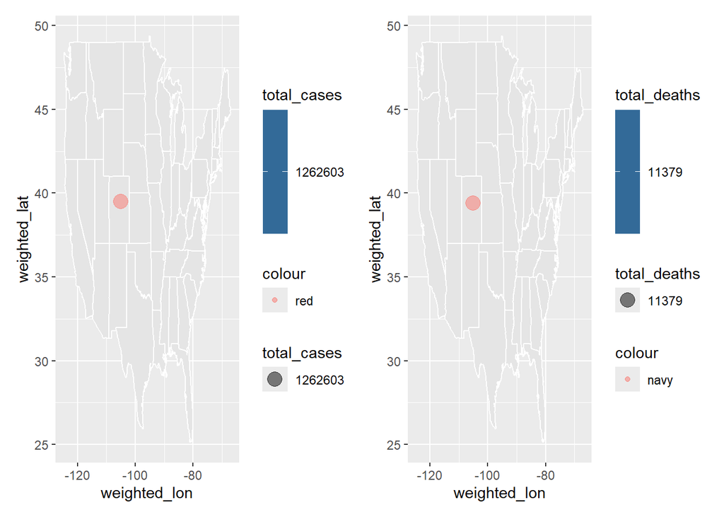

```r
# Create the plot for COVID cases
colorado_join <- centroids %>%
 inner_join(covid1, by =c("fips"="fips_code")) %>%
  group_by(date) %>%
  summarise(weighted_lon= sum(LON*cases) / sum(cases),
            weighted_lat = sum(LAT*cases) / sum(cases),
            total_cases = sum(cases)) %>%
  arrange(date) %>%
  mutate(d = 1:n())


plot_covid_cases <- colorado_join %>%
  filter(date == my.date) %>%
  ggplot(aes(x = weighted_lon, y = weighted_lat, fill = total_cases , color="red")) +
  borders("state", fill = "gray90", colour = "white") +
   geom_point(aes(x = weighted_lon, y = weighted_lat, color="red", size =total_cases), alpha=.50)
   # Rotate x labels for readability

# Create the plot for COVID deaths
colorado_join1 <- centroids %>%
 inner_join(covid1, by =c("fips"="fips_code")) %>%
  group_by(date) %>%
  summarise(weighted_lon= sum(LON*deaths) / sum(deaths),
            weighted_lat = sum(LAT*deaths) / sum(deaths),
            total_deaths = sum(deaths)) %>%
  arrange(date) %>%
  mutate(d = 1:n())

plot_covid_deaths <- colorado_join1 %>%
  filter(date == my.date) %>%
  ggplot(aes(x = weighted_lon, y = weighted_lat, fill = total_deaths , color="navy")) +
  borders("state", fill = "gray90", colour = "white") +
   geom_point(aes(x = weighted_lon, y = weighted_lat, color="navy", size =total_deaths), alpha=.50)

#combine plots side by side using pathwork
plot_covid_cases | plot_covid_deaths
```

# Once completed describe the differences in the plots and what they mean about the spatial patterns seen with COVID impacts.